# Coursework Report

*N* removed NAs: 7

*N* removed <18: 25

**Correct typo age:** 21

*N* total clean: 136

| Group | *N* | *M*<sub>age</sub> | % green |
| --- | --- | --- | --- |
| Control | 69 | 19.9 | 48.3 |
| Experim | 67 | 20.6 | 36.3 |

| Gender | *N* | *M*<sub>age</sub> | % green |
| --- | --- | --- | --- |
| Male | 67 | 20.2 | 40.3 |
| Female | 37 | 20.4 | 44.1 |
| Other | 32 | 20.3 | 44.8 |

**Main analysis results**

**car:**  
χ<sup>2</sup>(1) = 1.18, *p* = .277

**cleaner:**  
χ<sup>2</sup>(1) = 8.9, *p* = .003

**dishwasher:**  
χ<sup>2</sup>(1) = 0, *p* = 1.000

[interactive chart not shown]

[figure not shown]

[interactive chart not shown]

# Coursework Report

Analysing Data, Spring 2020

# Methods

## Participants

[output not shown]

**Table 1. Descriptive Statistics by Condition**

## Design

This experiment aimed to explore reasons why individuals may engage in pro-environmental choices. It was hypothesised that individuals may choose to purchase green products because of a desire to increase their social status. Activating status motives may influence an individual’s decision when choosing between luxurious non-green products and less luxurious, but environmentally friendly products. A between-subjects design was employed. The participants were split in two groups, a control and a status-driven condition, where they were asked to make choices between pro-environmental products and more luxurious but non-green ones. Participants in the two conditions were given a story to read before making each choice: the story was designed to evoke status-seeking motivations in the experimental condition, while the control group were given a similar story but that did not evoke status motives. The products participants had to make choices for were a dishwasher, a car and a cleaner. Each product had a non-green and a green variant, while the price stayed the same. The non-green product was meant to be more appealing in terms of functionality and durability and was considered as better, while the green product was meant to be more eco-friendly, but of poorer quality to the non-green product. It is predicted that participants would choose non-green products in the control condition, while participants in the status condition would choose green products. The prediction of this study was that activating status motives should lead individuals to choose green products over their non-green alternatives, as opposed to choosing non-green products when no status motives are present. We will test this with a Chi-squared statistical analysis to assess the likelihood of the outcome being due to chance.

# Results

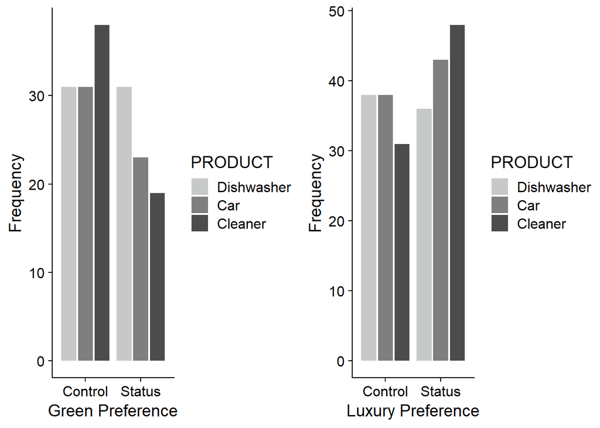

**Figure 1. Green and Luxury Preference for each Product per Condition**

Overall, the general pattern shows a decline in green preference when status motives where activated, and instead an increase in the choice for luxurious products between the control and status condition, as seen in Table 2. This contradicts the original hypothesis that status motives would lead to choosing green products as opposed to the control condition, therefore not supporting the findings of Griskevicius et al. (2010).

| Condition | Product | N | % |
| --- | --- | --- | --- |
| Control | Luxury | 107 | 26.3 |
| Control | Green | 100 | 24.6 |
| Status | Luxury | 127 | 31.2 |
| Status | Green | 73 | 17.9 |

**Table 2. Summary of Product Choice per Motive Condition**

# Discussion

This research aimed to explore why individuals engage in pro-environmental choices. The study conducted in this paper was an attempt to replicate the research carried by Griskevicius et al. (2010). Contrarily to their findings, this replication did not show that activating status motives would lead to pro-environmental choices over more luxurious non-environmental ones. Instead, it seemed to suggest it was actually the opposite - although significant results were only found a third of the time (cleaner product). Individuals chose fewer green products when status motives were elicited, and instead showed a propensity to choose more luxurious products instead, in comparison to the control condition where no status motives were aroused.

The main speculations as to why individuals may act in a self-sacrificing pro-environmental way were formulated according to previous research and theories such as Costly Signalling Theory and research on competitive altruism (Griskevicius et al., 2010), where individuals were supposed to engage in altruistic acts as to highlight their social role, social utility and social prowess. However, these results are more likely to support theories such Conspicuous Consumption (Sundie et al., 2011) and prestige motives (Harbaugh, 1998). These theories highlight how individuals are instead more driven to display shows of wealth and capability as a tool for attaining social status, instead of pro-social acts. Similarly, in a further experiment by Griskevicius et al. (2010), they showed evidence of how status motives increased green consumption especially when the green alternative was more expensive than its counterpart, thus suggesting a link between prestige and pro-sociality. It may be argued that such displays of wealth may be applied to pro-social situations independently as well. For example, individuals are likely to advertise their wealth through big charitable donations, with the amount donated functioning as a representation of the individual’s prestige and status (Harbaugh, 1998). It is just as likely that status motives were not in fact impactful on the participants’ decisions when contrasting green and luxurious products. Perhaps individuals simply chose the option that best suited themselves. However, this does not explain the observed increase in luxurious choices in the status motive condition, compared to the control condition, which are better accounted for by the aforementioned theories.

Additional variables have been explored as well, such as the effect of privacy on pro-environmental decisions. Individuals seem to behave in a more altruistic and pro-social manner when others are aware of their actions, as opposed to in a private setting (Hardy & Van Vugt, 2006). This is support by a third study run by where they explored the effect of a public setting on green product choices. Results showed people were more likely to shop green products in public, as opposed to luxurious products in a private setting (Griskevicius et al., 2010). Participants may have felt there was a lack of competitiveness for social status, whereby attaining a higher score would have made no difference considering the other participants would not know about it (Barclay, 2004).

In this experiment, such additional variables were not taken in consideration. Perhaps this may be an explanation as to why these results differ so greatly from the results found in the original study by Griskevicius et al. (2010), where participants did not consider their decisions on these products influencing or impacting their personal status in any direct way. Similarly, it is important to consider that the setting in which the choices are made will have a big impact on the outcome: different variables will contribute to status attainment in different contexts (DesJardins et al., 2015). A possible option for future replication could be running a within-subjects design to compare these effects in various controlled settings.

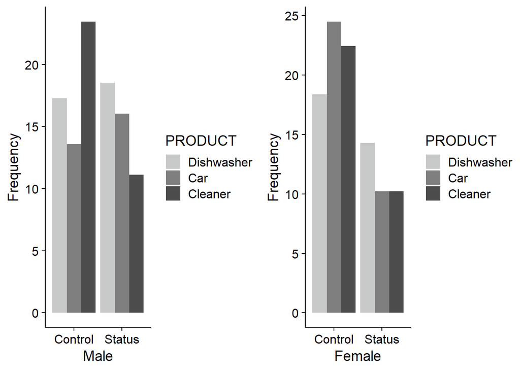

**Figure 2. Male and Female Green Preference per Condition**

# Conclusion

Overall, this study provides evidence against the hypothesis that activating status motives leads to an increased likelihood of choosing green products over non-green but more luxurious ones. Instead, an overall increase in luxurious products choices were observed when status motives were induced, as compared to the control condition. Various explanations are possible, but the main suggestions highlighted were in support of the conspicuous consumption theory, which sees individuals recur to vast displays of wealth to increase one’s status in a social setting, and of the prestige motivations, which increase an individual’s social status and ranking within a social setting. Knowing that wealth is a clear indicator of success and power, individuals would rather recur to such displays of luxury when status motives are activated, instead of employing a more altruistic approach through pro-sociality and pro-environmental views.

# References

Barclay, P. (2004). Trustworthiness and competitive altruism can also solve the “tragedy of the commons”. Evolution and Human Behavior, 25(4), 209–220. https://doi.org/10.1016/j.evolhumbehav.2004.04.002

DesJardins, N. M. L., Srivastava, S., Küfner, A. C. P., & Back, M. D. (2015). Who Attains Status? Similarities and Differences Across Social Contexts. Social Psychological and Personality Science, 6(6), 692–700. https://doi.org/10.1177/1948550615580171

Griskevicius, V., Tybur, J. M., & Van den Bergh, B. (2010). Going green to be seen: Status, reputation, and conspicuous conservation. Journal of Personality and Social Psychology, 98(3), 392–404. https://doi.org/10.1037/a0017346

Harbaugh, W. T. (1998). The Prestige Motive for Making Charitable Transfers. The American Economic Review, 88(2), 277–282.

Hardy, C. L., & Van Vugt, M. (2006). Nice Guys Finish First: The Competitive Altruism Hypothesis. Personality and Social Psychology Bulletin, 32(10), 1402–1413. https://doi.org/10.1177/0146167206291006

MacDonald, W. L., & Hara, N. (1994). Gender differences in environmental concern among college students. Sex Roles, 31(5), 369–374. https://doi.org/10.1007/BF01544595

Pinto, D. C., Herter, M. M., Rossi, P., & Borges, A. (2014). Going green for self or for others? Gender and identity salience effects on sustainable consumption. International Journal of Consumer Studies, 38(5), 540–549. https://doi.org/10.1111/ijcs.12114

Stern, P. C., Dietz, T., & Kalof, L. (1993). Value Orientations, Gender, and Environmental Concern. Environment and Behavior, 25(5), 322–348. https://doi.org/10.1177/0013916593255002

Sundie, J. M., Kenrick, D. T., Griskevicius, V., Tybur, J. M., Vohs, K. D., & Beal, D. J. (2011). Peacocks, Porsches, and Thorstein Veblen: Conspicuous consumption as a sexual signaling system. Journal of Personality and Social Psychology, 100(4), 664–680. https://doi.org/10.1037/a0021669